# UE20CS934 – Time Series Forecasting (TSF)

# ESA - Model Questions - Set 1

## Section - B

Analytics firm wants to forecast the average spending of customers for the month of Oct 2020. For this, firm has gathered a closing stock price data for the period of Feb 2019 to Sept 2020.

a) Read the dataset. What are the number of rows and no. of cols & types of variables? (2 mark)

b) Convert the data into time series (3 marks)

c) Check for defects in the data such as missing values, null, etc. (2 mark)

d) Visualize the time series using relevant plots. (3 mark)

e) Decompose the time series and check for components of time series. (4 marks)

f) Perform dicky fuller test to check the stationarity? What other actions will you take if series is non-stationary? (3+2 marks)

g) Plot Auto Correlation and Partial Auto Correlation function? What is your inference from these plots? (3+3 marks)

h) Split dataset into train and test sets. Use last two months of data for testing. (5 marks)

i) Fit ARIMA model and observe the RMSE and MAPE values of the model for test data. (10 marks)

### a) Read the dataset and find the number of rows, columns, and types of variables

```python
import pandas as pd

# Load the dataset
data = pd.read_csv("data_set.csv")

# Get the number of rows, columns, and types of variables
rows, cols = data.shape
data_types = data.dtypes

print(f"Number of rows: {rows}, Number of columns: {cols}")
print("Data types:\n", data_types)
```

```
Number of rows: 605, Number of columns: 2
Data types:
 Date             object
Avg spending    float64
dtype: object
```

### b) Convert the data into time series

```python
import pandas as pd

# Read the dataset
data = pd.read_csv("data_set.csv")

# Convert the 'Date' column to datetime format and set the frequency
data['Date'] = pd.to_datetime(data['Date'], dayfirst=True)
data.set_index('Date', inplace=True)
data = data.asfreq('D')  # 'D' stands for daily frequency

# Display the first few rows to verify
data.head()
```

| Date | Avg spending |
| --- | --- |
| 2019-02-04 | 62.58 |
| 2019-02-05 | 64.27 |
| 2019-02-06 | 63.44 |
| 2019-02-07 | 61.50 |
| 2019-02-08 | 61.16 |

### c) Check for defects in the data such as missing values, null, etc.

```python
missing_values = data.isnull().sum()
print("Missing Values:\n",missing_values)
```

```
Missing Values:
 Avg spending    0
dtype: int64
```

### d) Visualize the time series using relevant plots

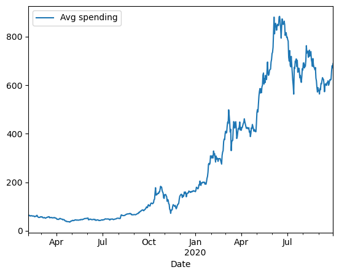

```python
data.plot()
```

### e) Decompose the time series and check for components of time series

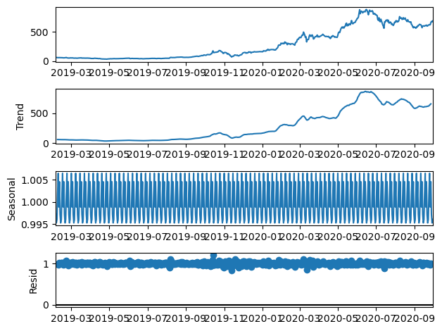

```python
from statsmodels.tsa.seasonal import seasonal_decompose

# Decompose using multiplicative model
decomposition = seasonal_decompose(data, model='multiplicative')

# Plot the decomposition
decomposition.plot()
plt.show()
```

### f) Perform Dickey-Fuller test to check the stationarity

```python
from statsmodels.tsa.stattools import adfuller

adf_result = adfuller(data.dropna())
print(f'ADF Statistic: {adf_result[0]}')
print(f'p-value: {adf_result[1]}')

if adf_result[1] > 0.05:
    print("Series is non-stationary, differencing required.")
else:
    print("Series is stationary.")
```

```
ADF Statistic: -0.30908265623618103
p-value: 0.9242080692970707
Series is non-stationary, differencing required.
```

```python
# Apply differencing
data_diff = data['Avg spending'].diff().dropna()
```

```python
# Re-check stationarity
adf_result_diff = adfuller(data_diff)
print(f'ADF Statistic after differencing: {adf_result_diff[0]}')
print(f'p-value after differencing: {adf_result_diff[1]}')

if adf_result_diff[1] > 0.05:
    print("Series is non-stationary, differencing required.")
else:
    print("Series is stationary.")
```

```
ADF Statistic after differencing: -6.731902702457794
p-value after differencing: 3.2798705231972727e-09
Series is stationary.
```

### g) Plot Auto Correlation and Partial Auto Correlation function

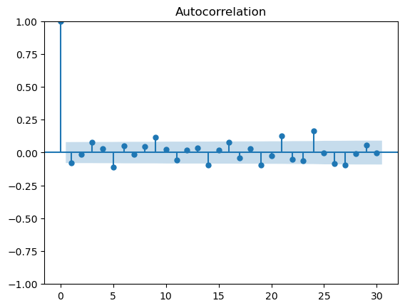

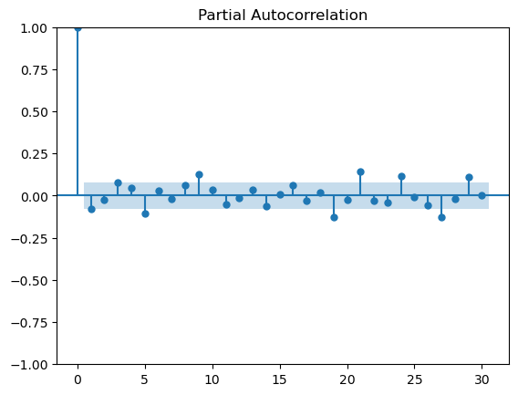

```python
from statsmodels.graphics.tsaplots import plot_acf, plot_pacf

# Plot ACF and PACF
plt.figure(figsize=(10, 6))
plot_acf(data_diff, lags=30)
plt.show()

plt.figure(figsize=(10, 6))
plot_pacf(data_diff, lags=30, method='ywm')
plt.show()
```

- From the PACF plot, the significant spike at lag 1 suggests p = 1.
- From the ACF plot, the significant spike at lag 1 suggests q = 1.

### h) Split Dataset into Train and Test Sets

```python
# Split the data into train and test sets
train = data[:'2020-07']
test = data['2020-08':]

print(f'Train set shape: {train.shape}')
print(f'Test set shape: {test.shape}')
```

```
Train set shape: (544, 1)
Test set shape: (61, 1)
```

### i) Fit ARIMA model and observe RMSE and MAPE values for test data

```python
from statsmodels.tsa.arima.model import ARIMA
from sklearn.metrics import root_mean_squared_error, mean_absolute_percentage_error

# Fit the ARIMA model
model = ARIMA(train['Avg spending'], order=(1, 1, 1))
model_fit = model.fit()

# Make predictions
predictions = model_fit.forecast(steps=len(test))
```

```python
# Calculate RMSE and MAPE
rmse = root_mean_squared_error(test['Avg spending'], predictions)
mape = mean_absolute_percentage_error(test['Avg spending'], predictions)

print(f'RMSE: {rmse}')
print(f'MAPE: {mape}')
```

```
RMSE: 55.45769961775811
MAPE: 0.07627183452255018
```

- RMSE of 55.46 suggests that, on average, the model’s predictions deviate from the actual values by about 55.46 units.
- A MAPE of 0.076 (or 7.63%): Generally, a MAPE below 10% is considered very good, indicating high accuracy.

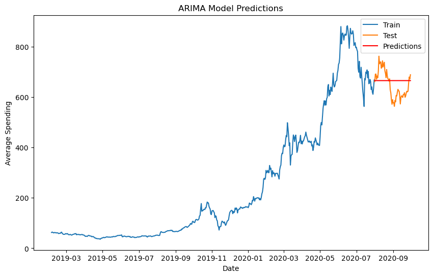

```python
# Plot the predictions
plt.figure(figsize=(10, 6))
plt.plot(train.index, train['Avg spending'], label='Train')
plt.plot(test.index, test['Avg spending'], label='Test')
plt.plot(test.index, predictions, label='Predictions', color='red')
plt.xlabel('Date')
plt.ylabel('Average Spending')
plt.title('ARIMA Model Predictions')
plt.legend()
plt.show()
```